# Statistical inference with the GSS data

## Setup

### Load packages

```r
library(ggplot2)
library(dplyr)
library(statsr)
```

### Load data

```r
load("gss.Rdata")
```

This is the dataset I will use for the project.

## Part 1: Data

The General Social Survey (GSS) is a survey that captures societal change and aims to understand complexities of American society. The survey has taken place annually since 1972. The survey is an observational study conducted in person using simple random sampling, however no random assignment was used. This allows generalizing but not inferring causation. The survey takes about 90 minutes to administer. As of 2014, 30 national samples with ~60k respondents and ~6k variables are collected. Participation is voluntarily, no random assignment of respondents.

The population of interest is the working US population therefore the results can be generalized to the US population.

*Bias*

In this dataset we can encounter potential bias given that the survey for year 2012 did not sample minors that could be working or people where English is not the first language. We need to keep this in mind as extrapolating the results to these categories would yield wrong results.

```r
# subset the data to consider more recent records after 2012
# ignore missing values records
# keep political views and confidence in governemnt variables: polviews, confed
# both are categorical variables
gss_pol <- gss %>% filter(year >= 2012 & !is.na(polviews) & !is.na(confed)) %>%
  select(polviews,confed)
dim(gss)
```

```
## [1] 57061   114
```

```r
dim(gss_pol)
```

```
## [1] 1252    2
```

I subset the data to consider more recent records after 2012 and ignore missing values records. The subset dataset has 1,252 records from a total of 57,061 records.

## Part 2: Research question

*My research topic is exploring the relationship between political views and confidence in the executive branch of federal government. I find this topic of high relevance in the current political climate.*

## Part 3: Exploratory data analysis

Using the head and tail function to visualize some records in the data.

```r
str(gss_pol)
```

```
## 'data.frame':    1252 obs. of  2 variables:
##  $ polviews: Factor w/ 7 levels "Extremely Liberal",..: 5 5 5 2 4 4 2 2 4 7 ...
##  $ confed  : Factor w/ 3 levels "A Great Deal",..: 2 2 3 1 3 3 1 2 3 2 ...
```

```r
head(gss_pol)
```

```
##                polviews       confed
## 1 Slightly Conservative    Only Some
## 2 Slightly Conservative    Only Some
## 3 Slightly Conservative   Hardly Any
## 4               Liberal A Great Deal
## 5              Moderate   Hardly Any
## 6              Moderate   Hardly Any
```

```r
tail(gss_pol)
```

```
##                   polviews     confed
## 1247  Extrmly Conservative  Only Some
## 1248          Conservative Hardly Any
## 1249               Liberal  Only Some
## 1250              Moderate Hardly Any
## 1251 Slightly Conservative  Only Some
## 1252              Moderate  Only Some
```

- The variables in the subset are both categorical with 7 and 3 levels.
- The variable **‘polviews’** indicates the political affiliation on a scale from extremely liberal to extremely conservative.
- The variable **‘confed’** states whatever the respondent has confidence in the federal government.

```r
pol.views <- table(gss_pol$polviews, useNA = "ifany")
# generate frequency table
pol.views
```

```
##
##     Extremely Liberal               Liberal      Slightly Liberal
##                    57                   156                   139
##              Moderate Slightly Conservative          Conservative
##                   465                   198                   189
##  Extrmly Conservative
##                    48
```

```r
# generate row percentages for frequency table
round(prop.table(pol.views) * 100,1)
```

```
##
##     Extremely Liberal               Liberal      Slightly Liberal
##                   4.6                  12.5                  11.1
##              Moderate Slightly Conservative          Conservative
##                  37.1                  15.8                  15.1
##  Extrmly Conservative
##                   3.8
```

```r
pol.confed <- table(gss_pol$confed, useNA = "ifany")
# generate frequency table
pol.confed
```

```
##
## A Great Deal    Only Some   Hardly Any
##          189          592          471
```

```r
# generate row percentages for frequency table
round(prop.table(pol.confed) * 100,1)
```

```
##
## A Great Deal    Only Some   Hardly Any
##         15.1         47.3         37.6
```

We notice that respondents with a great deal of confidence in the executive branch of the government are in a minority. In addition, ~38% have little confidence in the federal government.

```r
gss.pol <- table(gss_pol$polviews,gss_pol$confed)

# generate frequency table
gss.pol
```

```
##
##                         A Great Deal Only Some Hardly Any
##   Extremely Liberal               18        16         23
##   Liberal                         46        80         30
##   Slightly Liberal                25        76         38
##   Moderate                        65       239        161
##   Slightly Conservative           22       104         72
##   Conservative                     9        60        120
##   Extrmly Conservative             4        17         27
```

```r
# generate row percentages for frequency table
round(prop.table(gss.pol,1) * 100,1)
```

```
##
##                         A Great Deal Only Some Hardly Any
##   Extremely Liberal             31.6      28.1       40.4
##   Liberal                       29.5      51.3       19.2
##   Slightly Liberal              18.0      54.7       27.3
##   Moderate                      14.0      51.4       34.6
##   Slightly Conservative         11.1      52.5       36.4
##   Conservative                   4.8      31.7       63.5
##   Extrmly Conservative           8.3      35.4       56.2
```

```r
# generate column percentages for frequency table
round(prop.table(gss.pol,2) * 100,1)
```

```
##
##                         A Great Deal Only Some Hardly Any
##   Extremely Liberal              9.5       2.7        4.9
##   Liberal                       24.3      13.5        6.4
##   Slightly Liberal              13.2      12.8        8.1
##   Moderate                      34.4      40.4       34.2
##   Slightly Conservative         11.6      17.6       15.3
##   Conservative                   4.8      10.1       25.5
##   Extrmly Conservative           2.1       2.9        5.7
```

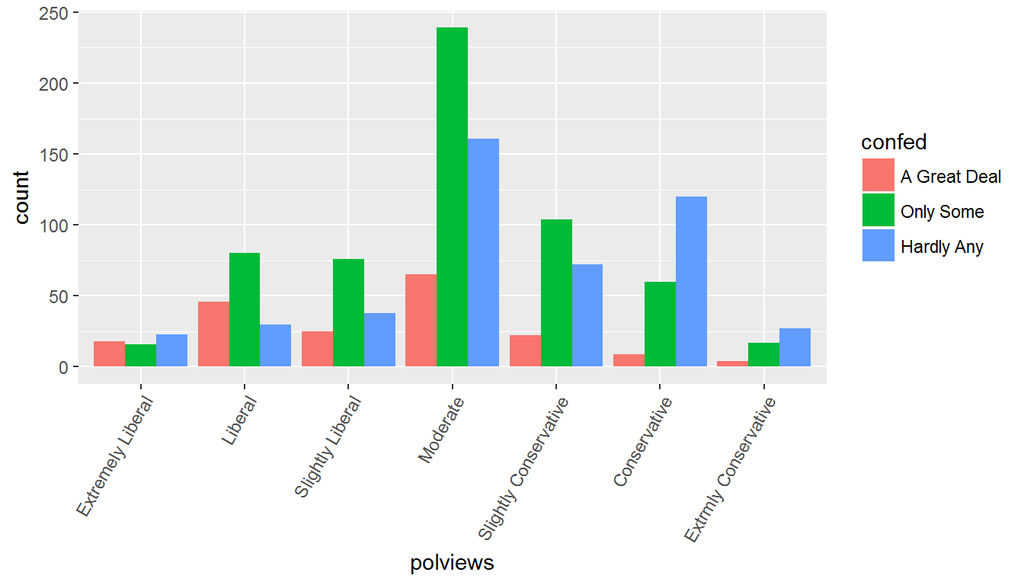

```r
g <- ggplot(data = gss_pol, aes(x=polviews)) +
  geom_bar(aes(fill=confed), position = "dodge") +
  theme(axis.text.x = element_text(angle = 60, hjust = 1))
g
```

#### Highlights:

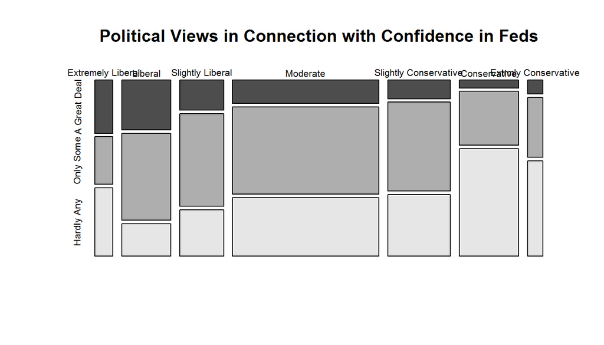

```r
 # plot(gss.pol)
mosaicplot(gss.pol, main = "Political Views in Connection with Confidence in Feds", color= TRUE )
```

In the above mosaic plot, the area of the tiles is proportional to the value counts within a group. When cells across groups all have similar sizes, it shows independence between the variables.

## Part 4: Inference

##### a. State hypotheses

- **Null hypothesis:** Political views and confidence in the executive branch of the government are *independent* (nothing is going on).
- **Alternative hypothesis:** Political views and confidence in the executive branch of the government are *dependent* (something is going on).

##### b. Check conditions

**Independence:** GSS dataset is generated from a random sampled survey and we can assume independence within groups and between groups. Each case only contributes to one cell in the table.

**Sample Size:** The subset I use has 1,252 records which is less than 10% of US population. For a chi-square test of independence it’s required to have at least 5 cases for each particular scenario/cell.

Next we’ll produce a chisquared table and analyse the results.

```r
chisq.test(gss_pol$polviews,gss_pol$confed)$expected
```

```
##                        gss_pol$confed
## gss_pol$polviews        A Great Deal Only Some Hardly Any
##   Extremely Liberal         8.604633  26.95208   21.44329
##   Liberal                  23.549521  73.76358   58.68690
##   Slightly Liberal         20.983227  65.72524   52.29153
##   Moderate                 70.195687 219.87220  174.93211
##   Slightly Conservative    29.889776  93.62300   74.48722
##   Conservative             28.531150  89.36741   71.10144
##   Extrmly Conservative      7.246006  22.69649   18.05751
```

Every cell has an expected count higher than 5.

**Degrees of Freedom:** We have 7 political views levels and 3 confidence levels for the two categorical variables. Calculated df=(7-1)x(3-1)=12 which is higher than 2.

##### c. State the method(s) to be used and why and how

I use *chi-square test of independence* since I am evaluating the relationship between two categorical variables. All conditions for the test are fulfilled.

##### d. Perform inference

```r
gss_chi_ind <- chisq.test(gss_pol$polviews,gss_pol$confed)

gss_chi_ind
```

```
##
##  Pearson's Chi-squared test
##
## data:  gss_pol$polviews and gss_pol$confed
## X-squared = 127.49, df = 12, p-value < 2.2e-16
```

The chi-squared statistic is 127.49, 12 degrees of freedom value and the p-value if very close to 0.

##### e. Interpret results

Since the p-value is lower than the significance level of 0.05 we conclude that we have convincing evidence to reject the null hypothesis in favour of the alternative hypostasis that the political views and confidence in the executive branch of the government are dependent.

The study being observational we can generalize that there is an association between the two variables but we cannot infer causation.